# DSC520 10.3 Final Project Part 3

Phil Han

8/14/2021

**For the Love of Games**

- Introduction

In the summer, there’s no other sport like baseball in American sports. Fans go to their team’s ball parks or stadiums to watch their favorite teams and players play while eating hot dogs and cold drinks. No wonder it is called National Pastime. The game filled with so many memorable moments and legends, like Babe Ruth and Ted Williams, have charmed the fans young and old. Once October arrives, the romance of the games in the summer gives way to an unscripted drama of Fall Classic games in the post season.

- Issues Addressed

However, in the recent years, baseball fans have been losing interest in the games and found baseball games to be either too long or boring. The attendance around the leagues has been steadily declining while fast-pace games like football and basketball have thrived in terms of popularity.

Theo Epstein, a former president of baseball operations for the Boston Red Sox and Chicago Cubs, recently said that he regretted that analytics used in the game has produced unintended consequences–less actions on the field (Svrluga, 2021).

- How Issues Are Addressed

This research paper seeks to find some of the main issues that might have contributed to the declining attendance for the games. It turned out that fans do not get to watch much action and athletic plays on the field when watching baseball games. Namely, there has been a decreasing number of doubles, triples, and stolen base produced on bases which all create more actions around the diamond.

I investigated whether or not there’s been a historical declining pattern with the above three categories. Specifically, I looked to see if the correlation among the attendance figures and the aforementioned three categories existed. If we can see the correlation, it will provide a clue as to how to fix the current problems that baseball is facing, if not at least help improve the game by introducing more action-inducing elements.

- Analysis

I looked at the over 100 years worth of the data on batting (doubles & triples) & stolen bases from *Sean Lahman’s Baseball Archive*. I also looked at the attendance data from *The Baseball Cube*. Because there’s an expansion of teams and the total number of teams vary over the years, I used the mean of the categories. And also, because the average attendance per game data only existed starting in 1950, I limited the size of the data to about 70 years (1950 - 2019). I did not use the data from 2020 since no fans, except for the postseason, were allowed during the pandemic shortened season.

| yearID | count_by_year | Avg_X2B | Avg_X3B | Avg_HR | Avg_SB | Avg_SO | Avg_X2B3B | Total_Attn | Teams | Games | Avg_TM_Attn | Avg_Attn_GM |
| --- | --- | --- | --- | --- | --- | --- | --- | --- | --- | --- | --- | --- |
| 1950 | 577 | 6.436742 | 1.3743501 | 3.592721 | 1.126516 | 16.55806 | 7.811092 | 17462977 | 16 | 1238 | 1091436 | 14106 |
| 1951 | 616 | 5.814935 | 1.1623377 | 3.024351 | 1.405844 | 15.15422 | 6.977273 | 16126676 | 16 | 1239 | 1007917 | 13016 |
| 1952 | 632 | 5.360759 | 1.0712025 | 2.691456 | 1.219937 | 16.42405 | 6.431962 | 14633044 | 16 | 1239 | 914565 | 11810 |
| 1953 | 586 | 6.131399 | 1.2713311 | 3.542662 | 1.139932 | 17.42833 | 7.402730 | 14383797 | 16 | 1240 | 898987 | 11600 |
| 1954 | 576 | 5.998264 | 1.3697917 | 3.362847 | 1.206597 | 17.73438 | 7.368056 | 15935883 | 16 | 1237 | 995993 | 12883 |
| 1955 | 655 | 4.963359 | 1.0687023 | 3.395420 | 1.059542 | 16.49313 | 6.032061 | 16617383 | 16 | 1234 | 1038586 | 13466 |
| 1956 | 621 | 5.376812 | 1.1674718 | 3.694042 | 1.157810 | 18.52657 | 6.544283 | 16543250 | 16 | 1239 | 1033953 | 13352 |
| 1957 | 615 | 5.521951 | 1.0926829 | 3.580488 | 1.247154 | 19.42764 | 6.614634 | 17015819 | 16 | 1235 | 1063489 | 13778 |
| 1958 | 638 | 5.316614 | 1.0266458 | 3.510972 | 1.161442 | 19.16144 | 6.343260 | 17460630 | 16 | 1235 | 1091289 | 14138 |
| 1959 | 632 | 5.503165 | 0.9351266 | 3.560127 | 1.349684 | 19.94304 | 6.438291 | 19143979 | 16 | 1238 | 1196499 | 15464 |
| 1960 | 637 | 5.403454 | 1.0329670 | 3.340659 | 1.448980 | 20.11774 | 6.436421 | 19911489 | 16 | 1236 | 1244468 | 16110 |
| 1961 | 698 | 5.694842 | 1.0802292 | 3.911175 | 1.498567 | 21.41404 | 6.775072 | 18894518 | 18 | 1430 | 1049695 | 13213 |
| 1962 | 760 | 5.675000 | 1.1223684 | 3.948684 | 1.773684 | 23.11447 | 6.797368 | 21375215 | 20 | 1621 | 1068761 | 13186 |
| 1963 | 752 | 5.449468 | 1.0518617 | 3.595745 | 1.643617 | 24.96410 | 6.501330 | 20477074 | 20 | 1619 | 1023854 | 12648 |
| 1964 | 754 | 5.663130 | 1.0079576 | 3.663130 | 1.559682 | 25.48011 | 6.671088 | 21280341 | 20 | 1626 | 1064017 | 13088 |
| 1965 | 751 | 5.591212 | 1.0479361 | 3.579228 | 1.929427 | 25.67643 | 6.639148 | 22441900 | 20 | 1623 | 1122095 | 13827 |
| 1966 | 774 | 5.322997 | 1.0594315 | 3.543928 | 1.879845 | 24.29587 | 6.382429 | 25182209 | 20 | 1615 | 1259110 | 15593 |
| 1967 | 786 | 5.193384 | 1.0076336 | 2.924936 | 1.746819 | 24.69847 | 6.201018 | 24308353 | 20 | 1620 | 1215418 | 15005 |
| 1968 | 715 | 5.411189 | 0.9748252 | 2.790210 | 2.118881 | 26.77343 | 6.386014 | 23102745 | 20 | 1625 | 1155137 | 14217 |
| 1969 | 932 | 5.193133 | 0.9109442 | 3.346567 | 1.984979 | 24.11266 | 6.104077 | 27229666 | 24 | 1946 | 1134569 | 13993 |
| 1970 | 919 | 5.696409 | 1.0087051 | 3.731230 | 2.076170 | 24.34603 | 6.705114 | 28747333 | 24 | 1944 | 1197806 | 14788 |
| 1971 | 883 | 5.584371 | 0.9150623 | 3.242356 | 1.998867 | 23.73273 | 6.499434 | 29193417 | 24 | 1938 | 1216392 | 15064 |
| 1972 | 889 | 5.232846 | 0.8391451 | 2.850394 | 2.032621 | 23.30484 | 6.071991 | 26968268 | 24 | 1859 | 1123678 | 14507 |
| 1973 | 892 | 5.856502 | 0.8856502 | 3.477578 | 2.280269 | 22.82287 | 6.742152 | 30108926 | 24 | 1943 | 1254539 | 15496 |
| 1974 | 914 | 5.695842 | 0.9266958 | 2.898249 | 2.722101 | 21.32932 | 6.622538 | 29576474 | 24 | 1945 | 1232353 | 15206 |
| 1975 | 907 | 6.001103 | 0.9779493 | 2.974642 | 2.782800 | 21.25689 | 6.979052 | 29347395 | 24 | 1934 | 1222808 | 15174 |
| 1976 | 886 | 5.914221 | 1.0902935 | 2.522573 | 3.446953 | 21.15688 | 7.004515 | 31318331 | 24 | 1939 | 1304930 | 16152 |
| 1977 | 984 | 6.545732 | 1.1890244 | 3.703252 | 3.066057 | 22.07520 | 7.734756 | 38709779 | 26 | 2103 | 1488838 | 18407 |
| 1978 | 960 | 6.443750 | 1.0625000 | 3.079167 | 3.129167 | 20.89375 | 7.506250 | 40636886 | 26 | 2102 | 1562957 | 19332 |
| 1979 | 961 | 6.675338 | 1.1092612 | 3.572320 | 3.104058 | 20.84807 | 7.784599 | 43550398 | 26 | 2099 | 1675015 | 20748 |
| 1980 | 950 | 6.678947 | 1.1326316 | 3.249474 | 3.467368 | 21.27579 | 7.811579 | 43014136 | 26 | 2105 | 1654390 | 20434 |
| 1981 | 944 | 4.237288 | 0.6980932 | 1.886653 | 2.140890 | 14.02225 | 4.935381 | 26544376 | 26 | 1394 | 1020938 | 19042 |
| 1982 | 992 | 6.366935 | 0.9717742 | 3.406250 | 3.201613 | 21.39214 | 7.338710 | 44587874 | 26 | 2107 | 1714918 | 21162 |
| 1983 | 1006 | 6.424453 | 1.0268390 | 3.281312 | 3.305169 | 21.58648 | 7.451292 | 45540338 | 26 | 2109 | 1751551 | 21593 |
| 1984 | 984 | 6.314024 | 1.0010163 | 3.310976 | 3.081301 | 22.86585 | 7.315041 | 44742863 | 26 | 2105 | 1720879 | 21256 |
| 1985 | 998 | 6.435872 | 0.9669339 | 3.609218 | 3.103206 | 22.49599 | 7.402806 | 46824379 | 26 | 2103 | 1800938 | 22266 |
| 1986 | 1017 | 6.402163 | 0.8407080 | 3.749263 | 3.256637 | 24.29302 | 7.242871 | 47506203 | 26 | 2103 | 1827162 | 22590 |
| 1987 | 1048 | 6.481870 | 0.8549618 | 4.253817 | 3.420802 | 23.94943 | 7.336832 | 52011506 | 26 | 2105 | 2000443 | 24709 |
| 1988 | 1035 | 6.170048 | 0.8115942 | 3.072464 | 3.189372 | 22.56522 | 6.981643 | 52998904 | 26 | 2100 | 2038419 | 25238 |
| 1989 | 1073 | 5.877912 | 0.8089469 | 2.873253 | 2.904007 | 22.04101 | 6.686859 | 55173096 | 26 | 2106 | 2122042 | 26198 |
| 1990 | 1115 | 5.852915 | 0.7757848 | 2.974888 | 2.950673 | 21.39283 | 6.628700 | 54823768 | 26 | 2105 | 2108606 | 26045 |
| 1991 | 1086 | 5.984346 | 0.8232044 | 3.115101 | 2.872928 | 22.45856 | 6.807551 | 56813760 | 26 | 2104 | 2185145 | 27003 |
| 1992 | 1066 | 6.156660 | 0.7926829 | 2.849906 | 3.061914 | 22.08068 | 6.949343 | 55870466 | 26 | 2106 | 2148864 | 26529 |
| 1993 | 1180 | 6.312712 | 0.7966102 | 3.415254 | 2.765254 | 22.29661 | 7.109322 | 70257938 | 28 | 2269 | 2509212 | 30964 |
| 1994 | 1030 | 5.556311 | 0.6815534 | 3.209709 | 2.192233 | 19.19029 | 6.237864 | 50010016 | 28 | 1600 | 1786072 | 31256 |
| 1995 | 1253 | 5.553073 | 0.6576217 | 3.256983 | 2.340782 | 20.29130 | 6.210694 | 50469236 | 28 | 2017 | 1802473 | 25022 |
| 1996 | 1253 | 6.374302 | 0.6823623 | 3.960096 | 2.584996 | 23.39026 | 7.056664 | 60097381 | 28 | 2267 | 2146335 | 26510 |
| 1997 | 1236 | 6.475728 | 0.7144013 | 3.754045 | 2.676375 | 24.22087 | 7.190129 | 63168689 | 28 | 2266 | 2256025 | 27877 |
| 1998 | 1322 | 6.611952 | 0.6800303 | 3.830560 | 2.484115 | 24.12481 | 7.291982 | 70601147 | 30 | 2432 | 2353372 | 29030 |
| 1999 | 1299 | 6.728253 | 0.7167052 | 4.255581 | 2.633564 | 23.95612 | 7.444958 | 70103204 | 30 | 2428 | 2336773 | 28873 |
| 2000 | 1384 | 6.431358 | 0.6878613 | 4.113439 | 2.112717 | 22.65607 | 7.119220 | 71358907 | 30 | 2429 | 2378630 | 29378 |
| 2001 | 1339 | 6.581777 | 0.6930545 | 4.076176 | 2.317401 | 24.20015 | 7.274832 | 72581101 | 30 | 2429 | 2419370 | 29881 |
| 2002 | 1319 | 6.595906 | 0.6982563 | 3.835481 | 2.084913 | 23.80136 | 7.294162 | 67944389 | 30 | 2426 | 2264813 | 28007 |
| 2003 | 1347 | 6.553081 | 0.6933927 | 3.865627 | 1.910171 | 22.86637 | 7.246474 | 67630052 | 30 | 2430 | 2254335 | 27831 |
| 2004 | 1346 | 6.626300 | 0.6671620 | 4.049777 | 1.923477 | 23.64636 | 7.293462 | 72989219 | 30 | 2428 | 2432974 | 30061 |
| 2005 | 1330 | 6.663910 | 0.6676692 | 3.772180 | 1.928571 | 23.04060 | 7.331579 | 74385295 | 30 | 2431 | 2479510 | 30599 |
| 2006 | 1377 | 6.633987 | 0.6913580 | 3.911402 | 2.009441 | 22.98838 | 7.325345 | 76043902 | 30 | 2429 | 2534797 | 31307 |
| 2007 | 1385 | 6.640433 | 0.6772563 | 3.579061 | 2.106859 | 23.24116 | 7.317690 | 79484718 | 30 | 2431 | 2649491 | 32696 |
| 2008 | 1385 | 6.508303 | 0.6397112 | 3.522022 | 2.020939 | 23.74296 | 7.148014 | 78591125 | 30 | 2428 | 2619704 | 32369 |
| 2009 | 1388 | 6.294669 | 0.6837176 | 3.632565 | 2.139769 | 24.20101 | 6.978386 | 73418528 | 30 | 2430 | 2447284 | 30213 |
| 2010 | 1356 | 6.258112 | 0.6386431 | 3.401917 | 2.182153 | 25.29941 | 6.896755 | 73061123 | 30 | 2430 | 2435371 | 30066 |
| 2011 | 1389 | 6.046796 | 0.6465083 | 3.277178 | 2.360691 | 24.82937 | 6.693305 | 73451522 | 30 | 2429 | 2448384 | 30239 |
| 2012 | 1408 | 5.867188 | 0.6583807 | 3.504261 | 2.293324 | 25.87074 | 6.525568 | 74859268 | 30 | 2430 | 2495309 | 30806 |
| 2013 | 1409 | 5.835344 | 0.5479063 | 3.308020 | 1.911285 | 26.05394 | 6.383251 | 74026895 | 30 | 2431 | 2467563 | 30451 |
| 2014 | 1435 | 5.670383 | 0.5916376 | 2.917073 | 1.926132 | 26.09129 | 6.262021 | 73739622 | 30 | 2430 | 2457987 | 30346 |
| 2015 | 1486 | 5.546433 | 0.6318977 | 3.303499 | 1.685734 | 25.19919 | 6.178331 | 73760032 | 30 | 2429 | 2458668 | 30366 |
| 2016 | 1483 | 5.565745 | 0.5886716 | 3.782873 | 1.710722 | 26.28591 | 6.154417 | 73159068 | 30 | 2428 | 2438636 | 30131 |
| 2017 | 1494 | 5.620482 | 0.5321285 | 4.086345 | 1.691432 | 26.84337 | 6.152610 | 72670423 | 30 | 2430 | 2422347 | 29906 |
| 2018 | 1535 | 5.383713 | 0.5517915 | 3.638436 | 1.611726 | 26.84495 | 5.935505 | 69649736 | 30 | 2431 | 2321658 | 28651 |
| 2019 | 1569 | 5.437221 | 0.5003187 | 4.318674 | 1.453155 | 27.29318 | 5.937540 | 68494845 | 30 | 2429 | 2283162 | 28199 |

First, I looked at the relationship between doubles hit (2B) and the average attendance per game(AAPG) based on the data I extracted. As you see 1) Scatter Plot with Regression Model below there is a positive correlation.

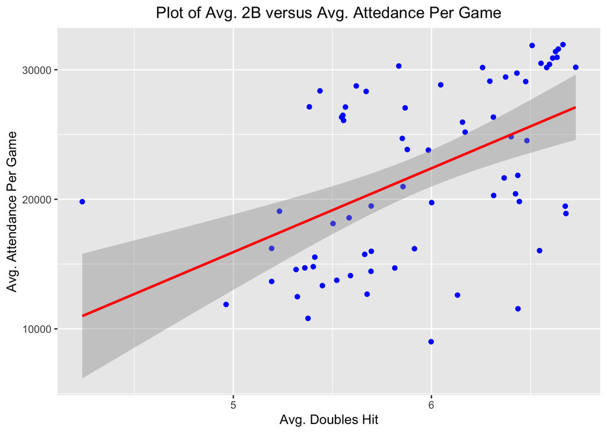

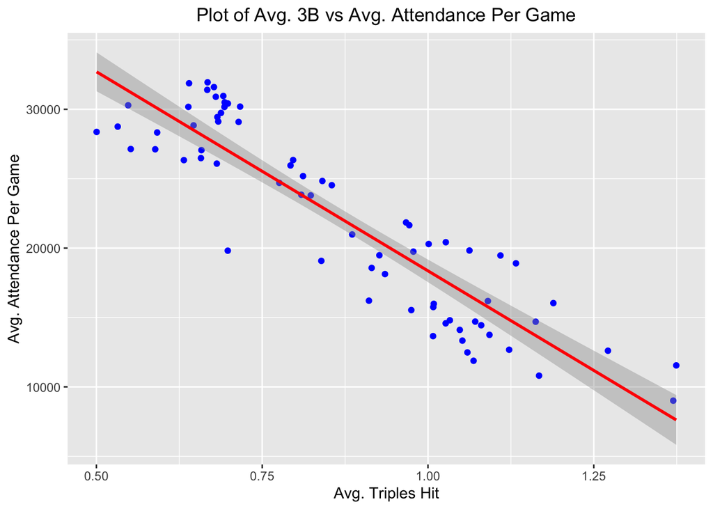

When looking at the relationship between the variables stolen base and AAPG, to my surprise, there doesn’t appear to be as a strong correlation as 2B and 3B versus AAPG.

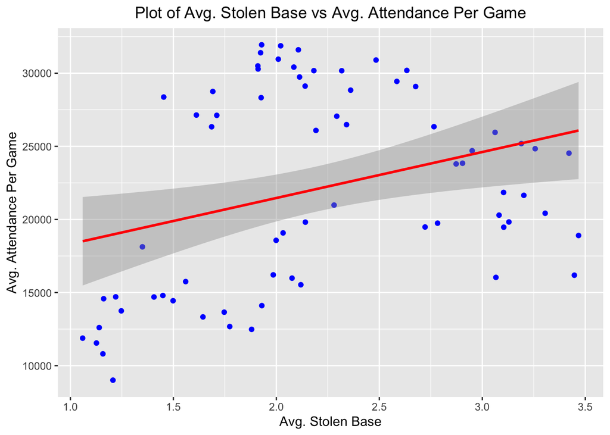

- Implications

Due to advanced analytics employed by the teams, defensive shifts have been used to prevent not only singles but also possible extra base hits have effectively reduced actions around the diamond. Also, the pitchers have used foreign substances to better grip the balls to increase spin rate and thus increase chances of strikeouts. In the meanwhile, hitters have focused on a launch angle to hit for home runs more than ever. And these two factors have led to a proliferation of more strikeouts, thus further reducing actions on the field.

- Additional Insights Gained

I made another model–a multiple regression model for strikeouts using extra base hit variables. Below is a summary data for the model to predict average strikeouts using all batting related variables.

```
##
## Call:
## lm(formula = Avg_SO ~ Avg_X2B + Avg_X3B + Avg_HR + Avg_SB, data = new_bb_data1)
##
## Residuals:
##     Min      1Q  Median      3Q     Max
## -7.0709 -0.8415 -0.1395  1.1318  6.3684
##
## Coefficients:
##             Estimate Std. Error t value Pr(>|t|)
## (Intercept)  22.7871     3.4104   6.682 6.31e-09 ***
## Avg_X2B      -1.5207     0.7527  -2.020  0.04748 *
## Avg_X3B      -6.3856     1.2674  -5.038 3.99e-06 ***
## Avg_HR        3.2057     0.7959   4.028  0.00015 ***
## Avg_SB        1.4757     0.5341   2.763  0.00744 **
## ---
## Signif. codes:  0 '***' 0.001 '**' 0.01 '*' 0.05 '.' 0.1 ' ' 1
##
## Residual standard error: 2.166 on 65 degrees of freedom
## Multiple R-squared:  0.4756, Adjusted R-squared:  0.4433
## F-statistic: 14.74 on 4 and 65 DF,  p-value: 1.277e-08
```

[figure not shown]

[figure not shown]

[figure not shown]

[figure not shown]

As P-values for the extra base hit variables such as doubles, triples, and home runs (or even a non-extra base hit variable like stolen bases) show, there is a clear relationship (i.e. less than 0.05) between the average strikeouts and the extra base hits that create actionable events on the field. Thus, the main implication of this researach is that Major League Baseball will need to tweak rules to lower strikeout rates and potentially prohibit defensive shifts.

- Limitations

One of the things that my analysis does not discuss is the category called slugging percentage (SLG), which represents the total number of bases a player records per at-bat. The formula for SLG is (1B + 2Bx2 + 3Bx3 _ HRx4)/AB where 1B stands for a single and AB stands for At-bat. Also, On base percentage (OBP) could have been factored into my analysis since OBP explains how hitters have avoided making an out by reaching base per plate appearance. Both metrics essentially measure how many times, or successfully, a hitter reaches base so the more players reach base, the more action-driven events may occur around the diamond. Including these categories may reveal even more insights pertaining to improving the game with entertaining and exciting actions.

- Conclusion

The game of baseball has evolved since the introduction of advanced analytics to help each team get advantages by unlocking hidden areas of the games through analyzing statistics of the players. However, it has brought unintended consequences of increasing strikeouts at a historically high rate while decreasing extra base hits that bring more action-filled events to the game. Thus, Major League Baseball needs to focus on how it can reduce the strikeout rate (i.e. a recent rule change to ban foreign substances used by pitchers) and implement and tweak rules to allow more extra base hits that are more inviting and exciting for the current and future fans.

- References:

Lahman, S. (n.d.). *Baseball Arhive*. SeanLahman.com. http://www.seanlahman.com/baseball-archive/

The Baseball Cube (n.d.). *MLB Attendance History*. thebaseballcube.com. http://www.thebaseballcube.com/topics/attendance/

Svrluga, B. (2021, July 15). *Baseball has lost its balance. Theo Epstein has some thoughts on restoring it*. washingtonpost.com. https://www.washingtonpost.com/sports/2021/07/15/theo-epstein-fixes-baseball/